# Report for a Data Analysis Project

**Authors**

- Anissa Waller Del Valle $^{1, *, \land}$
- Emil Joson $^{2, *}$

**Author affiliations**

1. Department of Cellular Biology, University of Georgia, Athens, GA, USA.
2. Department of Plant Pathology, University of Georgia, Athens, GA, USA.

$*$ These authors contributed equally to this work.

$\land$ Corresponding author: aw59557@uga.edu

# 1 Methods

## 1.1 Data acquisition

The dataset used in this study was provided with the data-analysis project template and can be found in data/raw-data. The dataset was updated to include two new variables, as described below.

## 1.2 Description of data and data source

Two new variables were added to the dataset and saved in exampledata2.xlsx. The first variable is age, reported as a numeric value >0 or non-applicable (NA) representing the age of each individual in years. The second variable is martial status, reported as either S (Single), M (Married), D (Divorced), W (Widowed), or NA. These variables are documented in the Codebook sheet of the updated dataset. Other variables include (1) height, reported in centimeters as a numeric value >0, (2) weight, reported in kilograms as a numeric value >0, and (3) gender, reported as either male, female, or other.

## 1.3 Data import and cleaning

Data import and cleaning were performed using scripts located in code/processing-code. This involved looking for obvious outliers (e.g., a weight of 7,000 kg) and removing them from the dataset, among other related processes. The cleaned dataset was saved as processeddata2.rds in the results directory for use in downstream analysis.

## 1.4 Statistical analysis

Exploratory data analysis was performed using the scripts in code/eda-code/eda-copy.qmd. A boxplot was generated to examine the distrubution of height in relation to marital status. A scatterplot was generated to examine the relationship between weight and age. These figures were saved to the results/figures directory.

Linear models were used to further explore the data. In addition to previously specified models, a third linear model was fit with height as the outcome and age and marital status as predictors. These were saved as resulttable3.rds in the results/able directory.

# 2 Results

## 2.1 Analysis

The dataset contained five variables: - Height, reported in centimeters. - Weight, reported in kilograms. - Gender, reported as either male, female, or other. - Age, reported in years. - Marital Status, reported as either single, married, divored, or widowed.

We first conducted exploratory analyses to examine the distributions of age, height, and weight. Figure Figure 1 shows the distribution of height. Figure Figure 2 shows the distribution of weight. Figure Figure 3 shows the distribution of age.

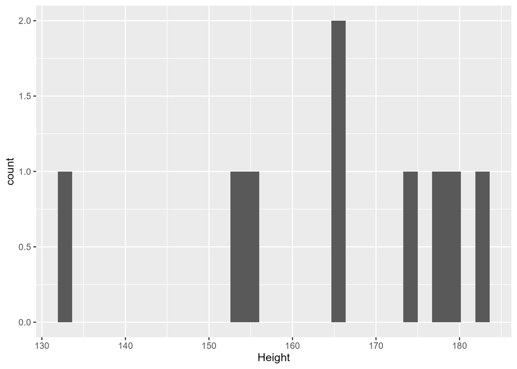

Figure 1: Distribution of Height

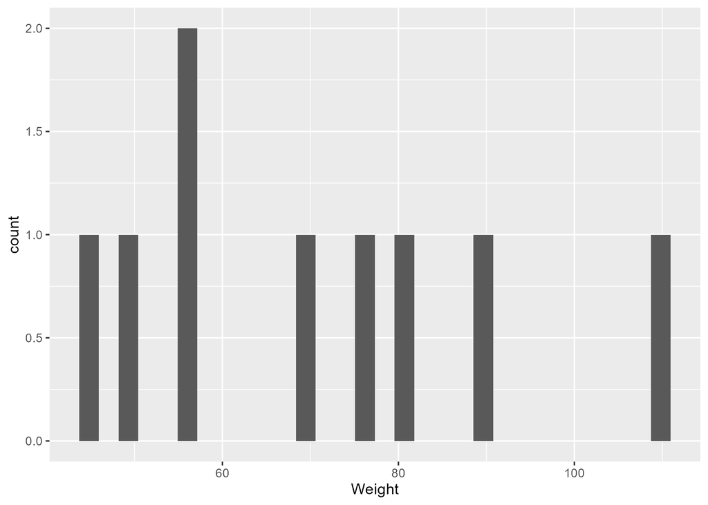

Figure 2: Distribution of Weight

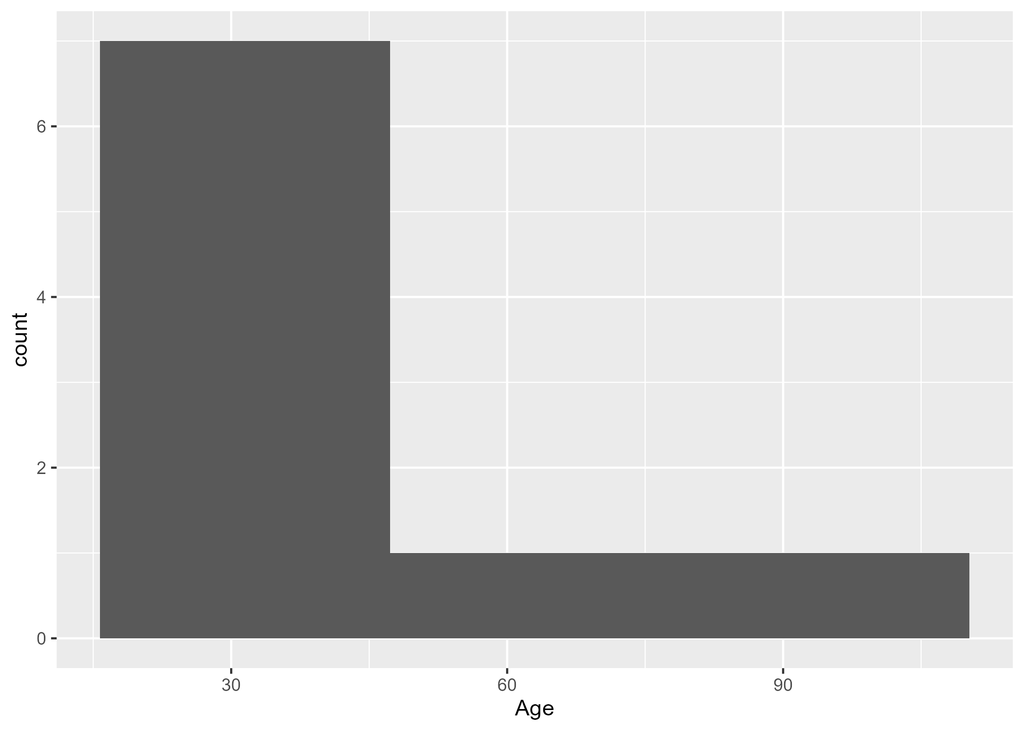

Figure 3: Distribution of Age

Figure 4 shows a scatterplot figure produced by one of the R scripts to visualize the relationship between height and weight stratified by gender.

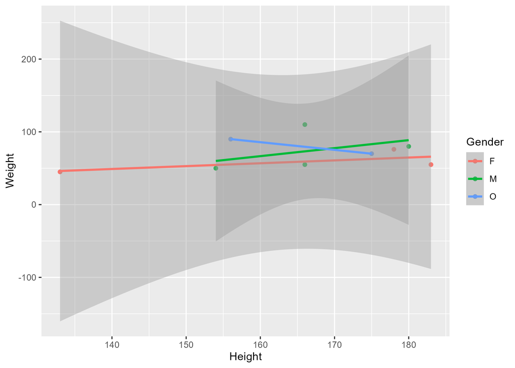

Figure 4: Height and weight stratified by gender.

Figure 5 shows the distribution of marital status. Figure 6 shows the boxplot generated in this analysis. Likewise, Figure 7 shows the scatterplot generated in this analysis.

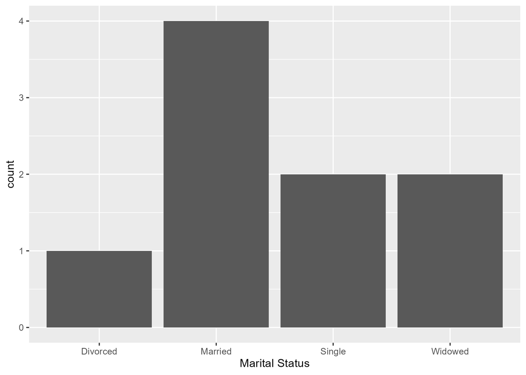

Figure 5: Distribution of Marital Status

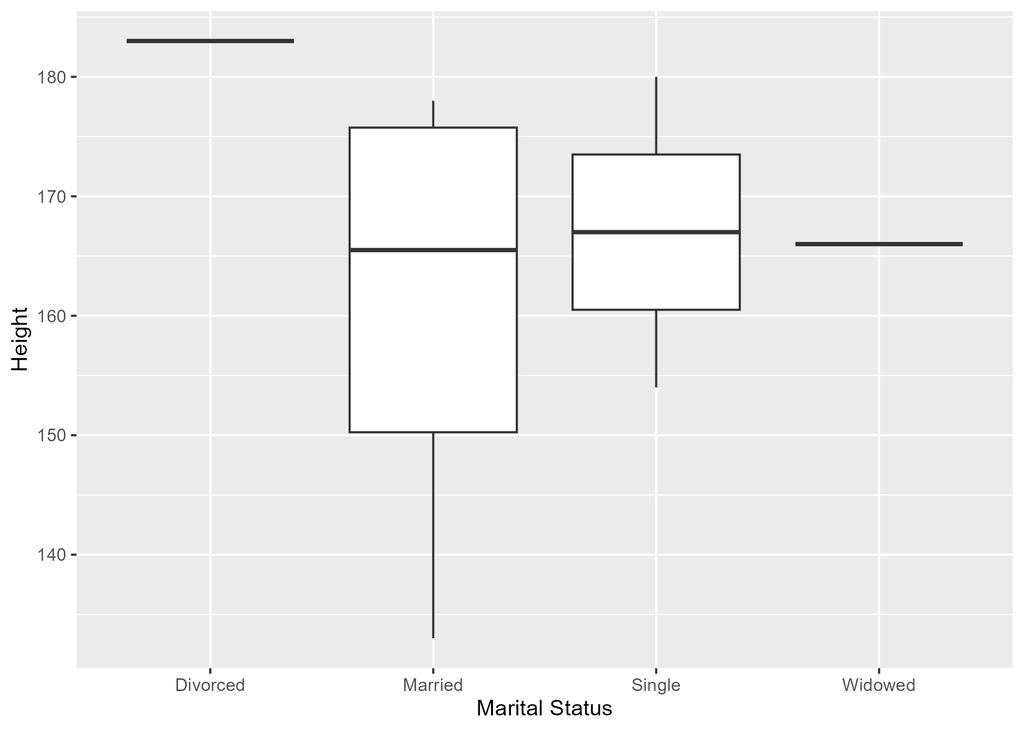

Figure 6: Marital Status vs. Height

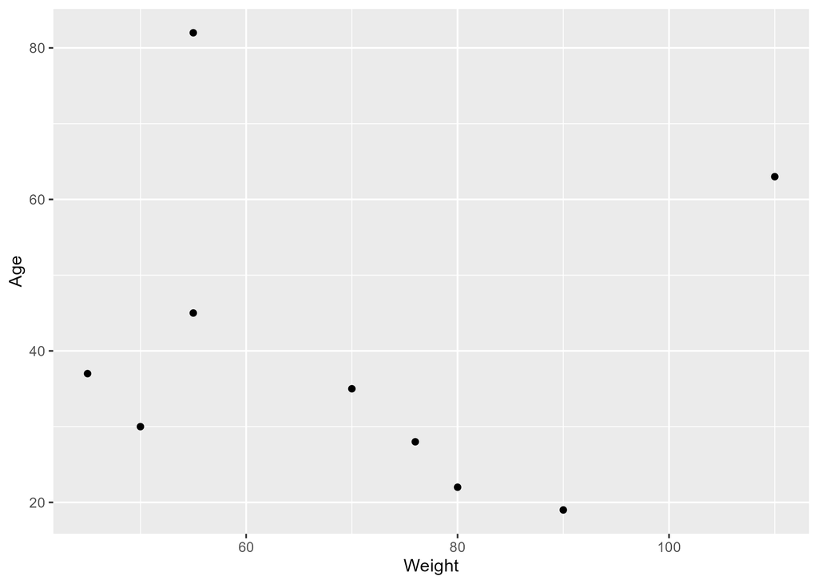

Figure 7: Age vs. Weight

Below is a summary of all linear model fits.

Table 2: Linear model fit table.

| term | estimate | std.error | statistic | p.value |
| --- | --- | --- | --- | --- |
| (Intercept) | 149.6997661 | 19.7518528 | 7.5790240 | 0.0001285 |
| Weight | 0.2277371 | 0.2708841 | 0.8407177 | 0.4282860 |

| term | estimate | std.error | statistic | p.value |
| --- | --- | --- | --- | --- |
| (Intercept) | 149.2726967 | 23.3823360 | 6.3839942 | 0.0013962 |
| Weight | 0.2623972 | 0.3512436 | 0.7470519 | 0.4886517 |
| GenderM | -2.1244913 | 15.5488953 | -0.1366329 | 0.8966520 |
| GenderO | -4.7644739 | 19.0114155 | -0.2506112 | 0.8120871 |

| term | estimate | std.error | statistic | p.value |
| --- | --- | --- | --- | --- |
| (Intercept) | 205.9240122 | 47.5127075 | 4.3340829 | 0.0123101 |
| Age | -0.5094225 | 0.9626066 | -0.5292115 | 0.6246660 |
| `Marital Status`M | -30.2686930 | 26.3026870 | -1.1507833 | 0.3139342 |
| `Marital Status`S | -25.6790274 | 30.1016654 | -0.8530766 | 0.4416881 |
| `Marital Status`W | -2.9908815 | 35.6700641 | -0.0838485 | 0.9372056 |